# lab 3 (2)

```python
import pandas as pd
import numpy as np
import matplotlib.pyplot as plt
import seaborn as sea
```

Spatial aggregation. [4 Marks]

1. Which state (consider all stations in that state) has the highest average PM2.5 concentration across all stations and across all years?

```python
#1
df=pd.read_csv('Data.csv')
df_grp=df.groupby('state')
df_avg=df_grp['PM2.5'].mean()
index_max=df_avg.idxmax()
print("The",index_max,"has the highest average PM2.5 concentration across all stations and across all years ")
```

```
The Delhi has the highest average PM2.5 concentration across all stations and across all years
```

2. Which state (consider all stations in that state) had the most days with hazardous PM2.5 levels (above 300 µg/m³) for the year 2023?

```python
pollution_df = pd.read_csv("Data.csv")
pollution_df['Timestamp'] = pd.to_datetime(pollution_df['Timestamp'])
mask_1 = pollution_df['Timestamp'].dt.year == 2023
mask_2 = pollution_df['PM2.5'] > 300

mask = mask_1 & mask_2
df_2023 = pollution_df[mask]
df_2023['Date'] = df_2023['Timestamp'].dt.date

hazardous_days = df_2023.groupby(['state', 'Date']).size().reset_index(name='Count')
hazardous_days_per_state = hazardous_days.groupby('state').size()

most_hazardous_state = hazardous_days_per_state.idxmax()
most_hazardous_days = hazardous_days_per_state.max()

print(f'The state with the most days with hazardous PM2.5 levels in 2023 is {most_hazardous_state} with {most_hazardous_days} days.\n')
```

```
The state with the most days with hazardous PM2.5 levels in 2023 is Delhi with 49 days.
```

3. Which state has the highest variability in PM2.5 levels across its monitoring stations in 2023? (Think how would you measure variability)

```python
#3
df_stdev=df_grp['PM2.5'].std()
index_max=df_stdev.idxmax()
print("The",index_max,"has the highest variability in PM2.5 levels across its monitoring stations in 2023 ")
```

[output not shown]

4. Which state has the lowest average PM2.5 levels during the Covid period (The year 2020-2021 both years inclusive)?

```python
#4
df['Timestamp']=pd.to_datetime(df['Timestamp'])
df_covid=df[df['Timestamp'].dt.year.isin([2020,2021])].groupby('state')
df_avg=df_covid['PM2.5'].mean()
print('The',df_avg.idxmin(),'has the lowest average PM2.5 levels during the covid year')
```

```
The Mizoram has the lowest average PM2.5 levels during the covid year
```

Temporal Aggregation [3 Marks]

1. Report the station that recorded the highest value of PM 2.5 for the month Aug of 2020.

```python
#1
df_aug_2020 = df[(df['Timestamp'].dt.year == 2020) & (df['Timestamp'].dt.month == 8)]
df_aug_2020_max = df_aug_2020.groupby('station')['PM2.5'].max()
highest_pm25_station = df_aug_2020_max.idxmax(skipna = True)
print("The station that recorded the highest value of PM 2.5 for the month Aug of 2020:", highest_pm25_station)
```

```
The station that recorded the highest value of PM 2.5 for the month Aug of 2020: Lal Bahadur Shastri Nagar, Kalaburagi - KSPCB
```

2. For the year 2018, calculate the average PM2.5 concentration for each season (Seasons being Winter: December-February, Summer: March-May, and Monsoon: June-September) for stations Lal Bahadur Shastri Nagar, Kalaburagi - KSPCB. Identifying the season with the highest pollution. [Thought Question] Can you suggest some potential factors on why certain seasons are generally more polluted than others?

```python
import pandas as pd

station_data = df[df['station'] == 'Lal Bahadur Shastri Nagar,Kalaburagi-KSPCB']
station_data = station_data.dropna()
station_data_2018 = station_data[station_data['Timestamp'].dt.year == 2018]

summer_avg = station_data_2018[station_data_2018['Timestamp'].dt.month.isin([3, 4, 5])]['PM2.5'].mean()
monsoon_avg = station_data_2018[station_data_2018['Timestamp'].dt.month.isin([6, 7, 8, 9])]['PM2.5'].mean()
winter_avg = station_data_2018[station_data_2018['Timestamp'].dt.month.isin([12, 1, 2])]['PM2.5'].mean()

if summer_avg > monsoon_avg and summer_avg > winter_avg:
    highest_pollution_season = "Summer"
elif monsoon_avg > summer_avg and monsoon_avg > winter_avg:
    highest_pollution_season = "Monsoon"
else:
    highest_pollution_season = "Winter"

print(f"Average PM2.5 concentration in Summer: {summer_avg:.2f}")
print(f"Average PM2.5 concentration in Monsoon: {monsoon_avg:.2f}")
print(f"Average PM2.5 concentration in Winter: {winter_avg:.2f}")
print(f"The season with the highest pollution in 2018 is: {highest_pollution_season}")
```

```
Average PM2.5 concentration in Summer: nan
Average PM2.5 concentration in Monsoon: nan
Average PM2.5 concentration in Winter: nan
The season with the highest pollution in 2018 is: Winter
```

3. Compare the average PM2.5 levels during weekends and weekdays for the station Lal Bahadur Shastri Nagar, Kalaburagi - KSPCB over the year 2021. Create a plot to show these trends Steps: Calculate the monthly average PM2.5 for weekdays and weekends separately X-axis: Months (January to December). Y-axis: Average PM2.5 levels. Use two lines: one for the monthly average PM2.5 levels on weekdays and one for weekends.

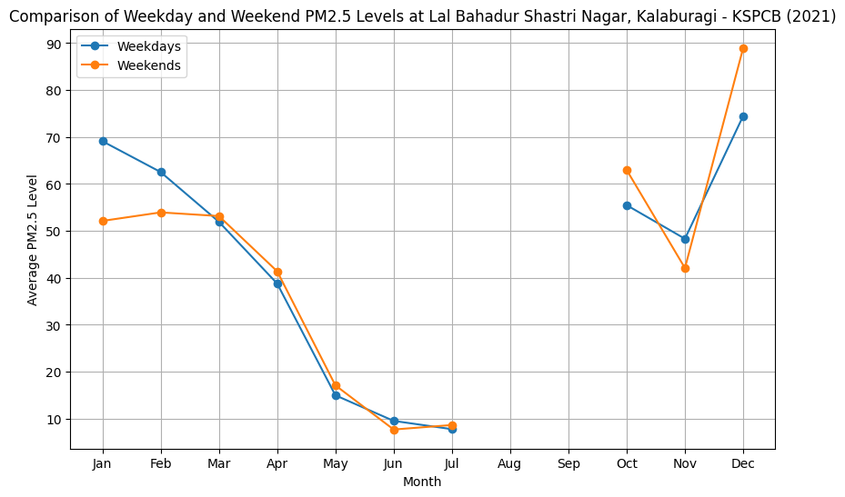

```python
#3
station_data = df[(df['station'] == 'Lal Bahadur Shastri Nagar, Kalaburagi - KSPCB')& (df['Timestamp'].dt.year == 2021)]
weekday_avg = []
weekend_avg = []
months = range(1, 13)
for month in months:
    weekday_data = station_data[(station_data['Timestamp'].dt.month == month)& (station_data['Timestamp'].dt.dayofweek.isin([0, 1, 2, 3, 4]))]
    weekend_data = station_data[(station_data['Timestamp'].dt.month == month)& (station_data['Timestamp'].dt.dayofweek.isin([5, 6]))]
    weekday_avg.append(weekday_data['PM2.5'].mean())
    weekend_avg.append(weekend_data['PM2.5'].mean())
plt.figure(figsize=(10, 6))
plt.plot(months, weekday_avg, label='Weekdays', marker='o')
plt.plot(months, weekend_avg, label='Weekends', marker='o')
plt.xlabel('Month')
plt.ylabel('Average PM2.5 Level')
plt.title('Comparison of Weekday and Weekend PM2.5 Levels at Lal Bahadur Shastri Nagar, Kalaburagi - KSPCB (2021)')
plt.xticks(months, ['Jan', 'Feb', 'Mar', 'Apr', 'May', 'Jun', 'Jul', 'Aug', 'Sep', 'Oct', 'Nov', 'Dec'])  # Set x-axis labels
plt.legend()
plt.grid(True)
plt.show()
```

Spatio-temporal aggregation [3 marks]

```python
#1
df_summer=df.query('Timestamp.dt.month.between(3,5) & Timestamp.dt.year==2022').groupby('state')
df_monsoon=df.query('Timestamp.dt.month.between(6,9) & Timestamp.dt.year==2022').groupby('state')
diff = ((df_summer['PM2.5'].mean() -df_monsoon['PM2.5'].mean())/df_monsoon['PM2.5'].mean())*100
print("The state",diff.idxmax(),'has the maximum percentage change in its pollution(PM2.5) in year 2022 and its percentage change is is',diff.max())
```

```
The state Assam has the maximum percentage change in its pollution(PM2.5) in year 2022 and its percentage change is is 157.575412362881
```

2. Plot the average PM2.5 levels for Delhi across each season (Winter: December-February, Summer: March-May, Monsoon: June-September) from 2017 to 2023. What seasonal variation, if any, can you observe in pollution levels?

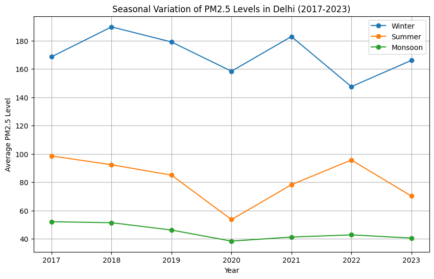

```python
#2
delhi_data = df[df['state'] == 'Delhi']
winter_avg = []
summer_avg = []
monsoon_avg = []
years = range(2017, 2024)
for year in years:
    winter_data = delhi_data[
        (delhi_data['Timestamp'].dt.year == year) &
        (delhi_data['Timestamp'].dt.month.isin([12, 1, 2]))
    ]
    summer_data = delhi_data[
        (delhi_data['Timestamp'].dt.year == year) &
        (delhi_data['Timestamp'].dt.month.isin([3, 4, 5]))
    ]
    monsoon_data = delhi_data[
        (delhi_data['Timestamp'].dt.year == year) &
        (delhi_data['Timestamp'].dt.month.isin([6, 7, 8, 9]))
    ]

    winter_avg.append(winter_data['PM2.5'].mean())
    summer_avg.append(summer_data['PM2.5'].mean())
    monsoon_avg.append(monsoon_data['PM2.5'].mean())

plt.figure(figsize=(10, 6))
plt.plot(years, winter_avg, label='Winter', marker='o')
plt.plot(years, summer_avg, label='Summer', marker='o')
plt.plot(years, monsoon_avg, label='Monsoon', marker='o')
plt.xlabel('Year')
plt.ylabel('Average PM2.5 Level')
plt.title('Seasonal Variation of PM2.5 Levels in Delhi (2017-2023)')
plt.legend()
plt.grid(True)
plt.show()
```

3. Plot a time-series graph comparing Delhi’s PM2.5 levels with Mumbai’s from 2017 to 2023. Which city had more fluctuations? (Hint: Think what fluctuation means)

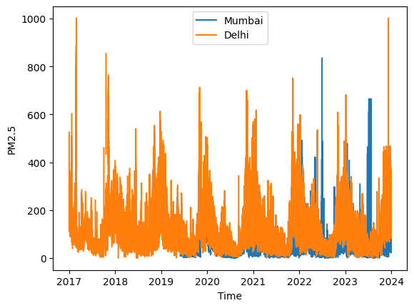

```
Fluctuation in Mumbai:  40.184004389169566
Fluctuation in Delhi:  84.93219895652578
Delhi had higher fluctuations
```

```python
#3
df_delhi = df[(df['city'] == 'Delhi') & (df['Timestamp'].dt.year >= 2015) & (df['Timestamp'].dt.year <= 2023)]
df_mumbai = df[(df['city'] == 'Mumbai') & (df['Timestamp'].dt.year >= 2015) & (df['Timestamp'].dt.year <= 2023)]
plt.plot(df_mumbai['Timestamp'], df_mumbai['PM2.5'], label='Mumbai')
plt.plot(df_delhi['Timestamp'], df_delhi['PM2.5'], label='Delhi')
plt.xlabel("Time")
plt.ylabel("PM2.5")
plt.legend()
plt.show()
print("Fluctuation in Mumbai: ", df_mumbai['PM2.5'].std(), "\nFluctuation in Delhi: ",df_delhi['PM2.5'].std())
print("Mumbai" if df_mumbai["PM2.5"].std() > df_delhi["PM2.5"].std() else "Delhi", "had higher fluctuations")
```

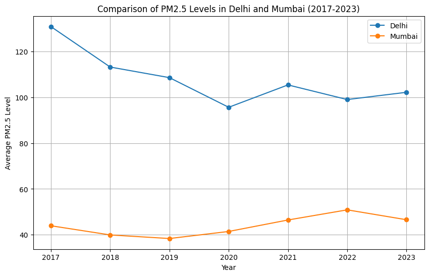

```
Delhi had more fluctuations in PM2.5 levels compared to Mumbai.
```

```python
delhi_data=df[df['state'] == 'Delhi']
mumbai_data=df[df['state'] == 'Maharashtra']
delhi_avg=[]
mumbai_avg=[]
years=list(range(2017,2024))
for year in years:
  delhi_avg.append(delhi_data[delhi_data['Timestamp'].dt.year == year]['PM2.5'].mean())
  mumbai_avg.append(mumbai_data[mumbai_data['Timestamp'].dt.year == year]['PM2.5'].mean())
plt.figure(figsize=(10, 6))
plt.plot(years, delhi_avg, label='Delhi', marker='o')
plt.plot(years, mumbai_avg, label='Mumbai', marker='o')
plt.xlabel('Year')
plt.ylabel('Average PM2.5 Level')
plt.title('Comparison of PM2.5 Levels in Delhi and Mumbai (2017-2023)')
plt.legend()
plt.grid(True)
plt.show()

delhi_std = delhi_data['PM2.5'].std()
mumbai_std = mumbai_data['PM2.5'].std()
if delhi_std > mumbai_std:
    print("Delhi had more fluctuations in PM2.5 levels compared to Mumbai.")
else:
    print("Mumbai had more fluctuations in PM2.5 levels compared to Delhi.")
```

Population-Based [3 Marks]

1. Which state in India has the highest number of monitoring stations relative to its population?

```python
#1
stations_count=df.groupby('state')['station'].count()
df_1=pd.read_csv('State_data.csv')
sorted_df_1 = df_1.sort_values(by=['State'], ascending=True)
stations_count=stations_count.reset_index()
sorted_df_1=sorted_df_1.reset_index()
MS_p=stations_count['station']/sorted_df_1['Population']
print('The state',sorted_df_1['State'].iloc[MS_p.idxmax()],"has the most relative no of stations by population")
```

```
The state Chandigarh has the most relative no of stations by population
```

2. Plot a bar chart showing the top 5 most polluted states in terms of per capita PM2.5 exposure in 2023.

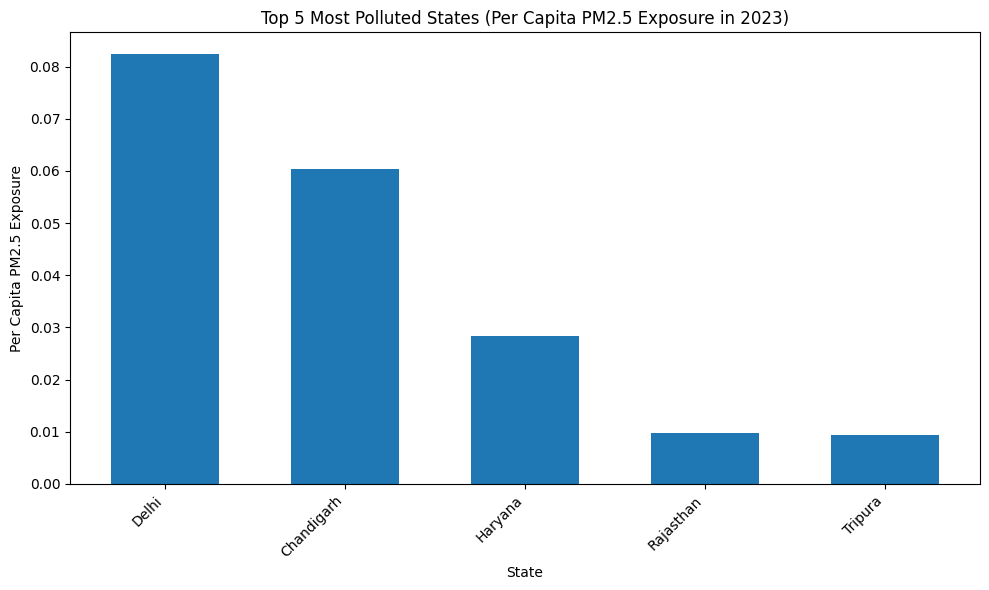

```python
polluted_state = df[df['Timestamp'].dt.year == 2023].groupby('state')
df_1 = df_1.sort_values(by=['State'])
per_capita_pm25 = polluted_state['PM2.5'].sum() / df_1.set_index('State')['Population']
top_5_states = per_capita_pm25.sort_values(ascending=False).head(5)

plt.figure(figsize=(10, 6))
plt.bar(top_5_states.index, top_5_states.values, width=0.6)
plt.title('Top 5 Most Polluted States (Per Capita PM2.5 Exposure in 2023)')
plt.xlabel("State")
plt.ylabel("Per Capita PM2.5 Exposure")
plt.xticks(rotation=45, ha='right')
plt.tight_layout()
plt.show()
```

3. Plot the relationship between population density and average PM2.5 concentration for each state. What conclusion can you draw about the correlation between population density and pollution? X-axis: Population density (people per square kilometer). Y-axis: Average PM2.5 concentration. Use a scatter plot to show the relationship, where each point represents a state.

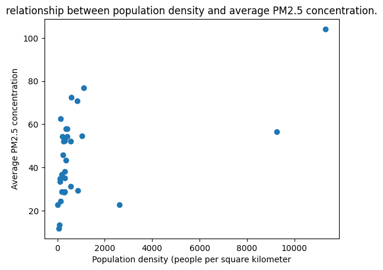

```python
#3
df_1=df_1.sort_values(by=['State'])
population_dens=df_1['Population']/df_1['Area (km2)']
mean=df.groupby('state')['PM2.5'].mean()
plt.scatter(population_dens.values,mean.values)
plt.xlabel("Population density (people per square kilometer")
plt.ylabel("Average PM2.5 concentration")
plt.title("relationship between population density and average PM2.5 concentration.")
```

Area Based [3 Marks]

1. Which state has the highest PM2.5 concentration per square kilometer? Plot the pollution levels for all states relative to their area. X-axis: States. Y-axis: PM2.5 concentration per square kilometer. Use a bar plot where each bar represents a state, and the height shows PM2.5 per sq km.

```
The state with the highest PM2.5 concentration per square kilometer is: Delhi
```

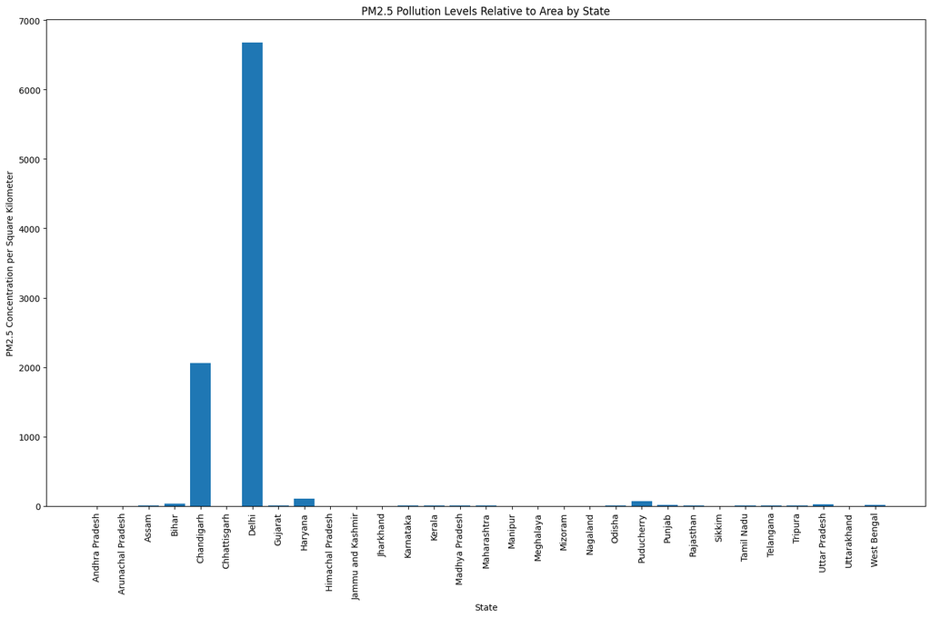

```python
#1
df_grp = df.groupby('state')['PM2.5'].sum()
conc_per_area = df_grp / df_1.set_index('State')['Area (km2)']
max_state = conc_per_area.idxmax()
print("The state with the highest PM2.5 concentration per square kilometer is:",max_state)
plt.figure(figsize=(15, 10))
plt.bar(conc_per_area.index, conc_per_area.values)
plt.xlabel("State")
plt.ylabel("PM2.5 Concentration per Square Kilometer")
plt.title("PM2.5 Pollution Levels Relative to Area by State")
plt.xticks(rotation=90)
plt.tight_layout()
```

2. Compare the total number of monitoring stations per square kilometer in each state. Identify the state with the highest density of monitoring stations relative to its area. Show a bar plot where each bar represents a state, and the height shows the number of monitoring stations per square kilometer.

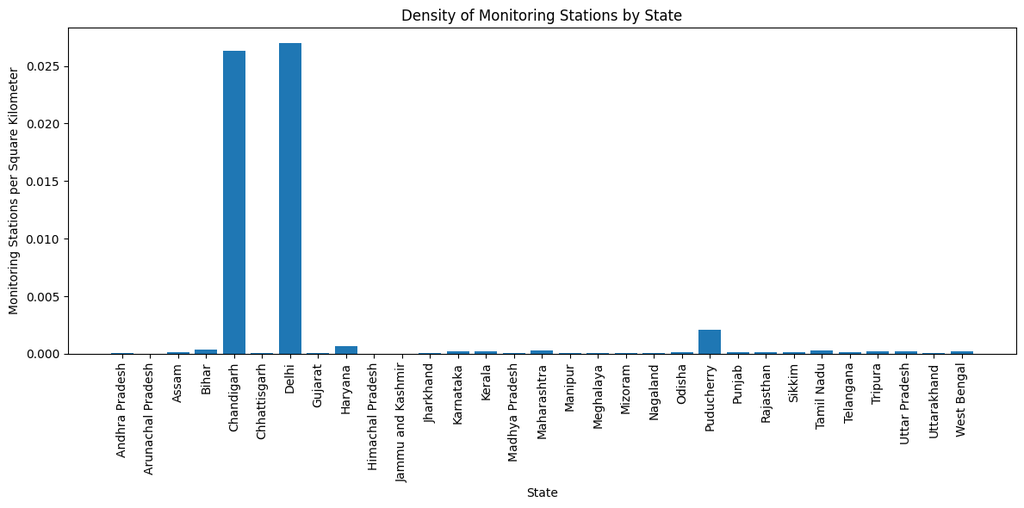

```
The state with the highest density of monitoring stations is: Delhi
```

```python
stations_per_state = df.groupby('state')['station'].nunique()
merged_data = pd.merge(stations_per_state, state_data, left_index=True, right_on='State')
merged_data['stations_per_sqkm'] = merged_data['station'] / merged_data['Area (km2)']
highest_density_state = merged_data.loc[merged_data['stations_per_sqkm'].idxmax(), 'State']

plt.figure(figsize=(12, 6))
plt.bar(merged_data['State'], merged_data['stations_per_sqkm'])
plt.xlabel("State")
plt.ylabel("Monitoring Stations per Square Kilometer")
plt.title("Density of Monitoring Stations by State")
plt.xticks(rotation=90)
plt.tight_layout()
plt.show()

print(f"The state with the highest density of monitoring stations is: {highest_density_state}")
```

3. Compare the average PM2.5 levels between Maharashtra and Madhya Pradesh over the year 2021. Given that both states have similar area sizes but different population densities, analyze how population density impacts pollution levels in these two states.

```
Average PM2.5 levels in 2021:
state
Madhya Pradesh    47.095952
Maharashtra       46.440044
Name: PM2.5, dtype: float64

Population densities (people per sq km):
State
Maharashtra       365.192023
Madhya Pradesh    235.608557
dtype: float64
```

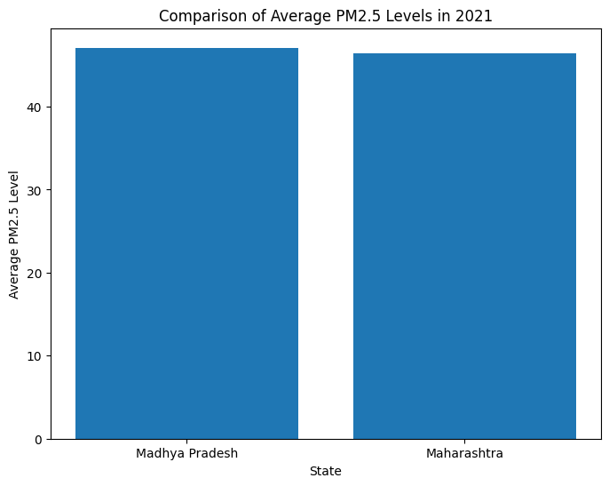

```
Analysis:
Madhya Pradesh has a higher average PM2.5 level in 2021.
Maharashtra has a higher population density.
The relationship between population density and PM2.5 levels is not straightforward in this case. Other factors might be influencing the pollution levels.
```

```python
#3
filtered_df = df[(df['Timestamp'].dt.year == 2021) & (df['state'].isin(['Maharashtra', 'Madhya Pradesh']))]
avg_pm25 = filtered_df.groupby('state')['PM2.5'].mean()
print("Average PM2.5 levels in 2021:")
print(avg_pm25)
population_densities = df_1.set_index('State').loc[['Maharashtra', 'Madhya Pradesh']]['Population'] / df_1.set_index('State').loc[['Maharashtra', 'Madhya Pradesh']]['Area (km2)']
print("\nPopulation densities (people per sq km):")
print(population_densities)
plt.figure(figsize=(8, 6))
plt.bar(avg_pm25.index, avg_pm25.values)
plt.xlabel("State")
plt.ylabel("Average PM2.5 Level")
plt.title("Comparison of Average PM2.5 Levels in 2021")
plt.show()
print("\nAnalysis:")
if avg_pm25['Maharashtra'] > avg_pm25['Madhya Pradesh']:
    higher_pollution_state = 'Maharashtra'
    lower_pollution_state = 'Madhya Pradesh'
else:
    higher_pollution_state = 'Madhya Pradesh'
    lower_pollution_state = 'Maharashtra'

print(higher_pollution_state, "has a higher average PM2.5 level in 2021.")

if population_densities['Maharashtra'] > population_densities['Madhya Pradesh']:
    higher_density_state = 'Maharashtra'
    lower_density_state = 'Madhya Pradesh'
else:
    higher_density_state = 'Madhya Pradesh'
    lower_density_state = 'Maharashtra'

print(f"{higher_density_state} has a higher population density.")

if higher_pollution_state == higher_density_state:
    print("This suggests that higher population density might contribute to higher PM2.5 levels, but further analysis is needed to confirm this relationship.")
else:
    print("The relationship between population density and PM2.5 levels is not straightforward in this case. Other factors might be influencing the pollution levels.")
```

Funding Based [3 Marks]

1. Compare the average PM2.5 levels between states that received NCAP funding and those that did not in 2021.

```python
data=pd.read_csv('Data.csv')
ncap=pd.read_csv('NCAP_Funding.csv')
state_data=pd.read_csv('State_data.csv')
```

```python
ncap.dtypes
```

|  | 0 |
| --- | --- |
| S. No. | int64 |
| State | object |
| City | object |
| Amount released during FY 2019-20 | object |
| Amount released during FY 2020-21 | object |
| Amount released during FY 2021-22 | object |
| Total fund released | float64 |
| Utilisation as on June 2022 | object |

**dtype:** object

```python
ncap.head()
```

|  | S. No. | State | City | Amount released during FY 2019-20 | Amount released during FY 2020-21 | Amount released during FY 2021-22 | Total fund released | Utilisation as on June 2022 |
| --- | --- | --- | --- | --- | --- | --- | --- | --- |
| 0 | 1 | Andhra Pradesh | Vijaywada | 6 | - | - | 6.00 | 22.91 |
| 1 | 2 | Andhra Pradesh | Guntur | 0.12 | 0.76 | 1.96 | 2.84 | 22.91 |
| 2 | 3 | Andhra Pradesh | Kurnool | 0.06 | 0.76 | 1.36 | 2.18 | 22.91 |
| 3 | 4 | Andhra Pradesh | Nellore | 0.06 | 0.76 | 1.92 | 2.74 | 22.91 |
| 4 | 5 | Andhra Pradesh | Visakhapatnam | 0.12 | - | - | 0.12 | 22.91 |

```python
ncap2=ncap.copy()
ncap2["Values 2021"]=ncap2["Amount released during FY 2021-22"].str.replace("-","0")
ncap2["Values 2021"]=ncap2["Values 2021"].astype(float)
display(ncap2.groupby("State")["Values 2021"].sum())
```

| State | Values 2021 |
| --- | --- |
| Andhra Pradesh | 11.48 |
| Assam | 0.00 |
| Bihar | 4.40 |
| Chandigarh | 4.61 |
| Chhattisgarh | 0.00 |
| Delhi | 11.25 |
| Gujarat | 0.00 |
| Himachal Pradesh | 0.48 |
| Jammu & Kashmir | 12.84 |
| Jharkhand | 0.00 |
| Karnataka | 7.32 |
| Madhya Pradesh | 5.02 |
| Maharashtra | 11.90 |
| Meghalaya | 0.00 |
| Nagaland | 0.93 |
| Odisha | 3.64 |
| Punjab | 0.00 |
| Rajasthan | 0.00 |
| Tamil Nadu | 0.00 |
| Telangana | 0.79 |
| Uttar Pradesh | 16.31 |
| Uttarakhand | 5.67 |
| West Bengal | 0.00 |

**dtype:** float64

```python
ncap_not_received=ncap2[ncap2["Values 2021"]==0]
display(ncap_not_received.groupby("State").groups.keys())
```

```
dict_keys(['Andhra Pradesh', 'Assam', 'Bihar', 'Chhattisgarh', 'Gujarat', 'Himachal Pradesh', 'Jharkhand', 'Karnataka', 'Madhya Pradesh', 'Maharashtra', 'Meghalaya', 'Odisha', 'Punjab', 'Rajasthan', 'Tamil Nadu', 'Telangana', 'Uttar Pradesh', 'Uttarakhand', 'West Bengal'])
```

```python
#1
mask=ncap2.groupby("State")["Values 2021"].sum()==0
zero_ncap_states=mask[mask].index
non_zero_ncap_states=mask[~mask].index
print(zero_ncap_states)
print(non_zero_ncap_states)
```

```
Index(['Assam', 'Chhattisgarh', 'Gujarat', 'Jharkhand', 'Meghalaya', 'Punjab',
       'Rajasthan', 'Tamil Nadu', 'West Bengal'],
      dtype='object', name='State')
Index(['Andhra Pradesh', 'Bihar', 'Chandigarh', 'Delhi', 'Himachal Pradesh',
       'Jammu & Kashmir', 'Karnataka', 'Madhya Pradesh', 'Maharashtra',
       'Nagaland', 'Odisha', 'Telangana', 'Uttar Pradesh', 'Uttarakhand'],
      dtype='object', name='State')
```

```python
display(data.head())
data.dtypes
```

|  | Timestamp | station | PM2.5 | PM10 | address | city | latitude | longitude | state |
| --- | --- | --- | --- | --- | --- | --- | --- | --- | --- |
| 0 | 2017-01-01 | 32Bungalows, Bhilai - CECB | NaN | NaN | Bhilai RO Office, 5, 32 Bungalows, Bhilai, Dis... | Bhilai | 21.194815 | 81.314770 | Chhattisgarh |
| 1 | 2017-01-01 | AIIMS, Raipur - CECB | NaN | NaN | All India Institute Of Medical Science, Gate N... | Raipur | 21.258815 | 81.578979 | Chhattisgarh |
| 2 | 2017-01-01 | Adarsh Nagar, Jaipur - RSPCB | NaN | NaN | Psychiatric Centre, Janta Colony, Govind Marg,... | Jaipur | 26.902909 | 75.836858 | Rajasthan |
| 3 | 2017-01-01 | Airoli, Navi Mumbai - MPCB | NaN | 54.743723 | NaN | Navi Mumbai | 19.149400 | 72.998600 | Maharashtra |
| 4 | 2017-01-01 | Airport Area, Indore - IMC | NaN | NaN | NaN | NaN | NaN | NaN | NaN |

|  | 0 |
| --- | --- |
| Timestamp | object |
| station | object |
| PM2.5 | float64 |
| PM10 | float64 |
| address | object |
| city | object |
| latitude | float64 |
| longitude | float64 |
| state | object |

**dtype:** object

```python
data2=data.copy()
data2["Timestamp"]=pd.to_datetime(data2["Timestamp"])
data2["Year"]=data2["Timestamp"].dt.year
```

```python
required_data_mask=data2["Year"]==2021
required_data=data2[required_data_mask].groupby("state")
display(len(required_data.groups.keys()))
```

```
31
```

```python
received_state_data=required_data.filter(lambda x: x["state"].iloc[0] in(non_zero_ncap_states))
not_received_state_data=required_data.filter(lambda x: x["state"].iloc[0] in(zero_ncap_states))
```

```python
print(received_state_data["PM2.5"].mean())
print(not_received_state_data["PM2.5"].mean())
```

```
65.35219325523295
51.27085382747028
```

```python
print(received_state_data.keys())
```

```
Index(['Timestamp', 'station', 'PM2.5', 'PM10', 'address', 'city', 'latitude',
       'longitude', 'state', 'Year'],
      dtype='object')
```

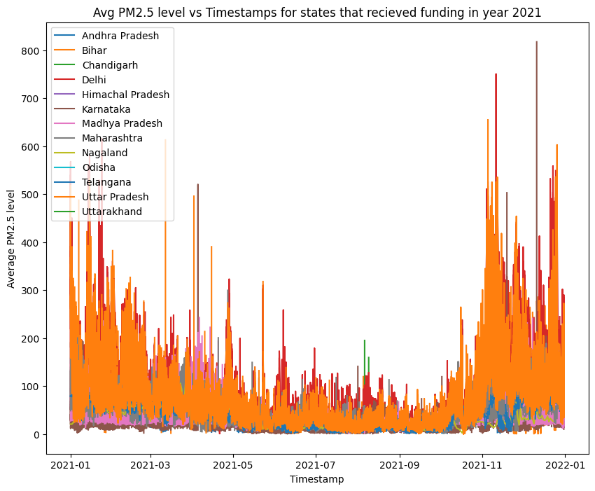

```python
plt.figure(figsize=(10,8))
for i in received_state_data.groupby("state"):
  plt.plot(i[1]["Timestamp"],i[1]["PM2.5"],label=i[0])
plt.xlabel('Timestamp')
plt.ylabel('Average PM2.5 level')
plt.title("Avg PM2.5 level vs Timestamps for states that recieved funding in year 2021")
plt.legend(loc="upper left")
plt.show()
```

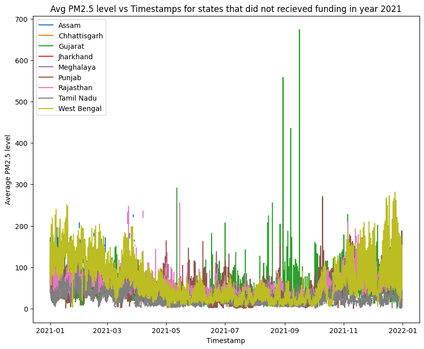

```python
plt.figure(figsize=(10,8))
for i in not_received_state_data.groupby("state"):
  plt.plot(i[1]["Timestamp"],i[1]["PM2.5"],label=i[0])
plt.xlabel('Timestamp')
plt.ylabel('Average PM2.5 level')
plt.title("Avg PM2.5 level vs Timestamps for states that did not recieved funding in year 2021")
plt.legend(loc="upper left")
plt.show()
```

```python
print(len(state_data[state_data["State"].isin(list(ncap.groupby("State").groups.keys()))]))
print(len(ncap[ncap["State"].isin(state_data[state_data["State"].isin(list(ncap.groupby("State").groups.keys()))].loc[:,"State"])].groupby("State").groups))
```

```
22
22
```

2. Create a time series plot showing PM2.5 levels with an increment in NCAP funding for Assam. Has an increment of the financing led to noticeable improvements in air quality?

[figure not shown]

```python
plt.plot(data.groupby("state").get_group("Assam")["Timestamp"],data.groupby("state").get_group("Assam")["PM2.5"])

plt.show()
```

3. Create a scatter plot to showcase the area versus funding received by a state. Mark every state with a different color and show the legend outside the plot.

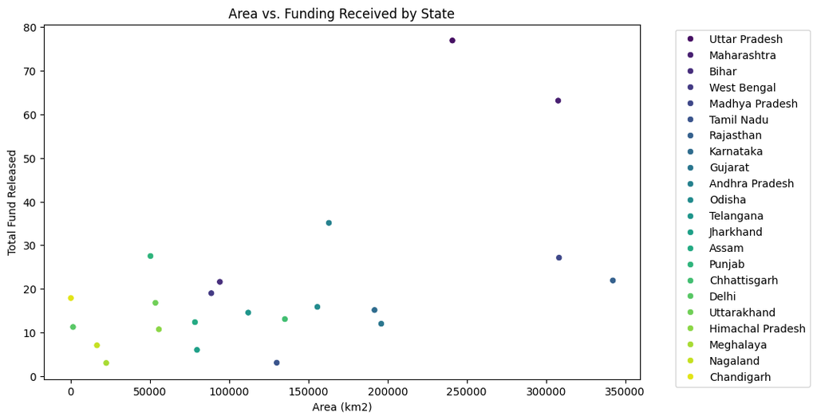

```python
filtered_state_data=state_data[state_data["State"].isin(ncap["State"].unique())]
funding_by_state=ncap.groupby("State")["Total fund released"].sum()
merged_data=pd.merge(filtered_state_data,funding_by_state,on="State")
plt.figure(figsize=(10,6))
sea.scatterplot(x="Area (km2)",y="Total fund released",hue="State",data=merged_data,palette="viridis")
plt.xlabel("Area (km2)")
plt.ylabel("Total Fund Released")
plt.title("Area vs. Funding Received by State")
plt.legend(bbox_to_anchor=(1.05,1),loc="upper left")
plt.show()
```

Miscellaneous Questions [5 Marks]

1. For the most polluted city in 2023 (highest average pollution in 2023), calculate the percentage of days with PM2.5 levels above the hazardous threshold (300 µg/m³)[1 Mark]

```python
most_polluted_city=data.groupby("city")["PM2.5"].sum().idxmax()
print(most_polluted_city)
```

```
Delhi
```

```python
above_threshold_days=data[(data["PM2.5"]>300)&(data["city"]==most_polluted_city)]
total_days=data[data["city"]==most_polluted_city]
print(len(above_threshold_days)/len(total_days)*100)
```

```
2.9136954924586194
```

2. Analyze the PM2.5 levels in Delhi during Diwali (October-November) and New Year compared to regular months over the 3 years (2018-2020). Do you observe any significant pollution spikes during these festivals? If spikes are observed, Can you mark these spikes using arrows?[1.5 Mark]

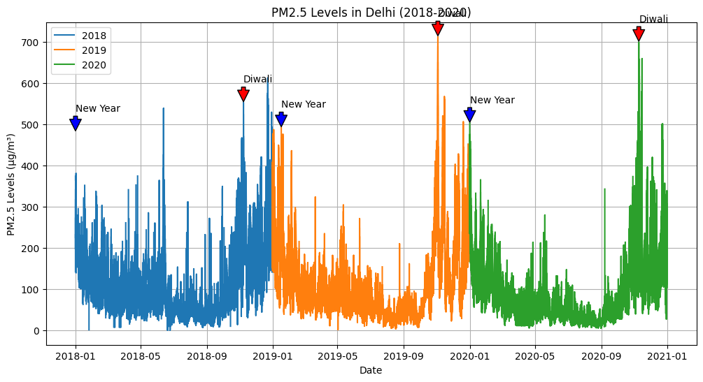

```python
data['Timestamp'] = pd.to_datetime(data['Timestamp'], format='%Y-%m-%d')


delhi_data = data[(data['city'] == 'Delhi') & (data['Timestamp'].dt.year.isin([2018, 2019, 2020]))]

delhi_data['Month'] = delhi_data['Timestamp'].dt.month
delhi_data['Day'] = delhi_data['Timestamp'].dt.day


diwali_months = [10, 11]
new_year_month = 1


plt.figure(figsize=(12, 6))


for year in [2018, 2019, 2020]:
    yearly_data = delhi_data[delhi_data['Timestamp'].dt.year == year]
    plt.plot(yearly_data['Timestamp'], yearly_data['PM2.5'], label=f'{year}')


    diwali_data = yearly_data[yearly_data['Month'].isin(diwali_months)]
    if not diwali_data.empty:
        diwali_peak = diwali_data.loc[diwali_data['PM2.5'].idxmax()]
        plt.annotate('Diwali', xy=(diwali_peak['Timestamp'], diwali_peak['PM2.5']),
                     xytext=(diwali_peak['Timestamp'], diwali_peak['PM2.5'] + 50),
                     arrowprops=dict(facecolor='red', shrink=0.05))

    new_year_data = yearly_data[yearly_data['Month'] == new_year_month]
    if not new_year_data.empty:
        new_year_peak = new_year_data.loc[new_year_data['PM2.5'].idxmax()]
        plt.annotate('New Year', xy=(new_year_peak['Timestamp'], new_year_peak['PM2.5']),
                     xytext=(new_year_peak['Timestamp'], new_year_peak['PM2.5'] + 50),
                     arrowprops=dict(facecolor='blue', shrink=0.05))

plt.xlabel('Date')
plt.ylabel('PM2.5 Levels (µg/m³)')
plt.title('PM2.5 Levels in Delhi (2018-2020)')
plt.legend()
plt.grid(True)
plt.show()
```

3. Identify the state that received the highest NCAP funding in 2020 and determine if its air pollution levels improved significantly by 2023. Use a line graph to compare yearly average PM2.5 trends.[1 Mark]

```python
ncap.dtypes
```

|  | 0 |
| --- | --- |
| S. No. | int64 |
| State | object |
| City | object |
| Amount released during FY 2019-20 | object |
| Amount released during FY 2020-21 | object |
| Amount released during FY 2021-22 | object |
| Total fund released | float64 |
| Utilisation as on June 2022 | object |

**dtype:** object

```python
highest_funded_state_2020=ncap.groupby("State")["Amount released during FY 2020-21"].sum().idxmax()
print(highest_funded_state_2020)
```

```
Assam
```

```python
required_data=data[(data["state"]==highest_funded_state_2020)&(data["Timestamp"].dt.year.isin([2020,2021,2022,2023]))]
```

```python
required_data["PM2.5"].fillna(required_data["PM2.5"].mode(),inplace=True)
```

```python
required_data['Year'] = required_data['Timestamp'].dt.year
```

```python
grouped_data_year=required_data.groupby("Year")
```

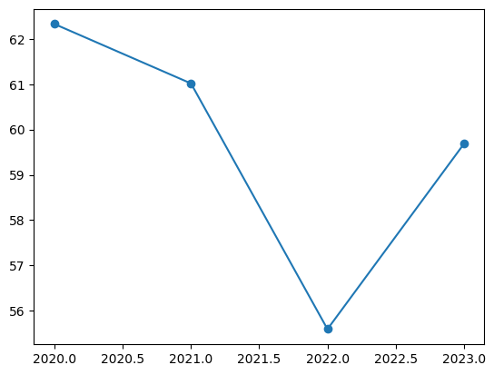

```python
plt.plot(grouped_data_year.groups.keys(),grouped_data_year["PM2.5"].mean(),label="Mean PM2.5",marker="o")
plt.show()
```

4. Draw the map of India and plot the sensor locations on the map.[1.5 Mark]

```python
!pip install cartopy
import cartopy
```

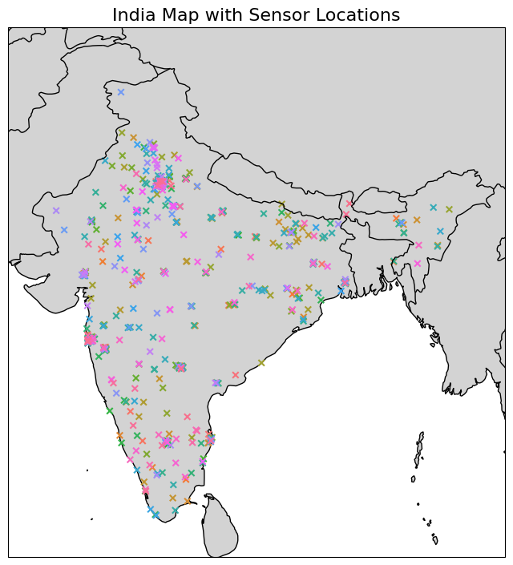

```python
import cartopy.crs as ccrs
import cartopy.feature as cfeature

df_cpy_123 = data[['city','longitude', 'latitude', 'station']]
df_cpy_123=df_cpy_123.drop_duplicates(subset=['station'])

# Create a figure with a Cartopy GeoAxes projection (PlateCarree is common for lat/lon data)
fig, ax = plt.subplots(figsize=(8, 10), subplot_kw={'projection': ccrs.PlateCarree()})

# Add Natural Earth features (land and borders)
ax.add_feature(cfeature.LAND, edgecolor="black", facecolor="lightgray")
ax.add_feature(cfeature.BORDERS, edgecolor="black")

# Set the map extent to cover India: [lon_min, lon_max, lat_min, lat_max]
ax.set_extent([68, 98, 6, 38], crs=ccrs.PlateCarree())

colors = sea.color_palette("husl", df_cpy_123.shape[0])

ax.scatter(df_cpy_123['longitude'], df_cpy_123['latitude'],
           color=colors, marker='x',edgecolor="black", s=30,
           transform=ccrs.PlateCarree(),
           label="Sensor Locations")
# Add title and legend
plt.title("India Map with Sensor Locations", fontsize=16)


plt.savefig("plot.png", dpi=300, bbox_inches='tight')
plt.show()
```

Tell us something new [1 Mark]

1. Tell us something interesting from the dataset that we have not asked. Anything that intrigues you, anything that might be useful to the policymakers.

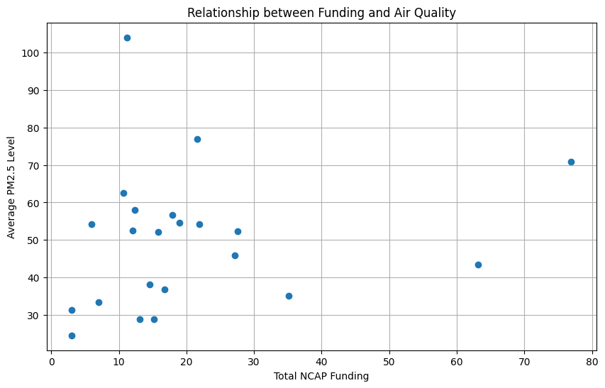

```python
funding_by_state = ncap.groupby('State')['Total fund released'].sum()
avg_pm25_by_state = data.groupby('state')['PM2.5'].mean()
merged_data = pd.merge(funding_by_state, avg_pm25_by_state, left_index=True, right_index=True)
plt.figure(figsize=(10, 6))
plt.scatter(merged_data['Total fund released'], merged_data['PM2.5'])
plt.xlabel('Total NCAP Funding')
plt.ylabel('Average PM2.5 Level')
plt.title('Relationship between Funding and Air Quality')
plt.grid(True)
plt.show()
```